# Applied Machine Learning Assignment 1

# Desmond Ajayi

## R00194774

# Load Libraries

```python
import os
import numpy as np
import pandas as pd
import seaborn as sns
import matplotlib.pyplot as plt
import re
import glob
sns.set(style='white', context='notebook', palette='deep')
%matplotlib inline
pd.set_option('display.max_colwidth', -1)
from wordcloud import WordCloud
from sklearn.feature_extraction.stop_words import ENGLISH_STOP_WORDS
import nltk
```

# Import Data

The dataset was loaded into 2 DataFrames for Ham and Spam. I looped through all the text files in both the Ham and Spam directories and then read them. While also reading the files and appending the contents, I replaced all new lines with spaces and converted all the text to lower cases. I also created a new response variable and assigned it **1** if it is **SPAM** and **0** if it is **HAM**

```python
ham_list = []
path="/Users/desmondajayi/Documents/Msc Data Science Analytics/Semester 2/Machine Learning/Assignment 1/enron1/ham" #my document's path
all_files = glob.glob(os.path.join(path, "*.txt"))  #Used to concatenate the file names with my path name

for f in all_files:
    with open (f, "r") as myfile:
        ham_list.append(myfile.read().lower().replace('\r', ' ').replace('\n', ' ')) #read the data in as lower case and remove new lines.

ham = pd.DataFrame(ham_list,columns=["Emails"])
ham["Type"]=0 #Assign Ham as 0
```

```python
spam_list = []
path="/Users/desmondajayi/Documents/Msc Data Science Analytics/Semester 2/Machine Learning/Assignment 1/enron1/spam" #my document's path
all_files = glob.glob(os.path.join(path, "*.txt"))     # advisable to use os.path.join as this makes concatenation OS independent

for f in all_files:
    with open (f, "r",encoding="ISO-8859-1") as myfile:
        spam_list.append(myfile.read().lower().replace('\r', ' ').replace('\n', ' ')) #read the data in as lower case and remove new lines.

spam = pd.DataFrame(spam_list,columns=["Emails"])
spam["Type"]=1 #Assign Spam as 1
```

Another dataframe was created to then hold both the Ham and Spam data.

```python
#Add both ham and spam to a dataframe
hamSpamData= pd.concat([ham,spam])
```

I then visualized the classes of the dataset and noticed that the data is imbalanced as there are more **HAM** than **SPAM**. The visualizations below shows the proportions.

```
0    3672
1    1500
Name: Type, dtype: int64
```

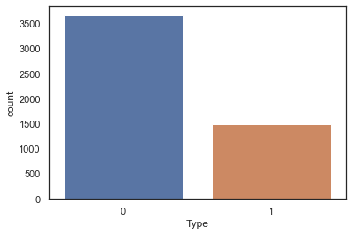

```python
print(hamSpamData["Type"].value_counts()) #Print the count of each class
sns.countplot("Type",data=hamSpamData) #Plot the count of each class
```

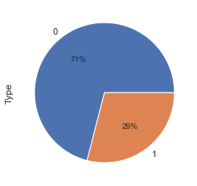

```python
hamSpamData["Type"].value_counts().plot.pie(autopct='%1.0f%%') #Plot a pie chart of the proportion of each class and rounded to the nearest whole number.
```

```python
hamSpamData.isnull().any() #Check for null values in any of the columns
```

```
Emails    False
Type      False
dtype: bool
```

# Preprocessing

## Clean the Data

The first thing I did here was to clean the data. While randomly going through the dataset, I noticed some issues with the data:

1. The data contains web links but the url's are seperated by spaces e.g "http : / google . co"
2. The data contains lots of characters and numbers.
3. The data contains many whitespaces.
4. The data contains some single characters.

```python
#Remove non alphabets(Numbers and punctuation marks)
import re
hamSpamData["Emails"] = [re.sub('[^a-zA-Z]',' ',doc) for doc in hamSpamData["Emails"] ]
```

```python
# Substituting multiple spaces with a single space
hamSpamData["Emails"] = [re.sub('\s+',' ',doc) for doc in hamSpamData["Emails"] ]
```

```python
# remove all single characters
hamSpamData["Emails"] = [re.sub('\s+[a-zA-Z]\s+',' ',doc) for doc in hamSpamData["Emails"] ]
```

```python
# remove parts of web url and also the word "Subject"
hamSpamData["Emails"] = [re.sub('http','',doc) for doc in hamSpamData["Emails"] ]
hamSpamData["Emails"] = [re.sub('www','',doc) for doc in hamSpamData["Emails"] ]
hamSpamData["Emails"] = [re.sub('nbsp','',doc) for doc in hamSpamData["Emails"] ]
hamSpamData["Emails"] = [re.sub('subject','',doc) for doc in hamSpamData["Emails"] ]
hamSpamData["Emails"] = [re.sub('com','',doc) for doc in hamSpamData["Emails"] ]
```

# Split Data

I first seperated both the explanatory and response variable into two different variables.I then split my data using the train_test_split function in Scikt Learn using a test size of 30% and also set a random state of 42 for reproducibility. The class distribution for both the test and train dataset was also plotted. This also shows an imbalance as we have more Ham data.

```python
from sklearn.model_selection import train_test_split
X = hamSpamData["Emails"]
Y = hamSpamData["Type"]

X_train, X_test, Y_train, Y_test = train_test_split(X, Y, test_size = 0.3, random_state = 42)
```

```
0    2552
1    1068
Name: Type, dtype: int64
```

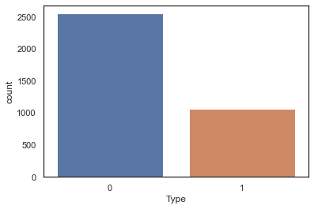

```python
#Distribution of our classes in the train set
print(Y_train.value_counts()) #Prints count of class
sns.countplot(Y_train) #Plots count of class
```

```
0    1120
1    432
Name: Type, dtype: int64
```

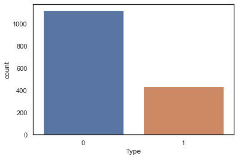

```python
#Distribution of our classes in the test set
print(Y_test.value_counts()) #Print count of class
sns.countplot(Y_test) #Plots count of class
```

# Exploratory Data Analysis

In order to explore the data and have an idea of the kinds of words in both the Ham and Spam Dataset, I used a wordcloud to visualize the words and its frequency. To have a better understanding of the words, I plotted 2 wordcloud for each class using a unigram and bigram. The unigram just takes into consideration a single word when plotting the wordcloud while a bigram takes into considerations 2 words. This was done to see if there was a better context to the words.

## Unigram

We can see from the wordcloud for Ham emails that the words "ect","hou","enron"and "Deal" have higher frequencies that other words. The word "enron" is popular because that is the name of the corporation and since its a corporate mail box, there would be lots of mails across collegues which would contain the host name in the email address. Also, the word "Deal" is popular as the company was a very big energy company therefore there would have been lots of mails about engaging in various types of deals. Words like contract and volume can also be seen in the wordcloud which also validates the earlier statement.

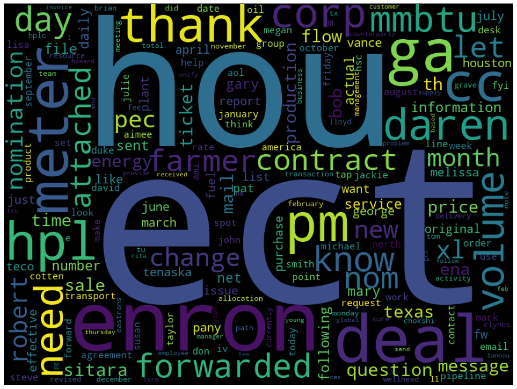

```python
#Word Cloud for Ham Emails
ham_emails = ' '.join(X_train[Y_train==0]) #Create one list consisting of all ham emails.

ham_wc = WordCloud(width=800,
                         height=600,
                         stopwords=ENGLISH_STOP_WORDS,collocations=False).generate(ham_emails)

# Display the generated image:
plt.subplots(figsize=(16, 12))
plt.imshow(ham_wc)
plt.axis("off")
plt.show()
```

The top 20 words in the Ham Emails were also looked at. This is shown below as it shows their relative frequencies. We can see that the word "ect" has a very high relative frequency when compared to the other words.

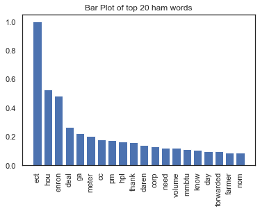

```python
#Relative frequency of the top 20 Ham words
#converted dictionary to a list then sliced list and finally converted it back to a dictionary
top_20_ham=dict(list(ham_wc.words_.items())[:20])

plt.bar(top_20_ham.keys(),top_20_ham.values())
plt.xticks(rotation='90')
plt.title("Bar Plot of top 20 ham words")
plt.show()
```

From the Spam wordcloud, we can see that the words "pany","price","new"and "font" have higher frequencies that other words. The wordcloud below gives an overview of the popular words.

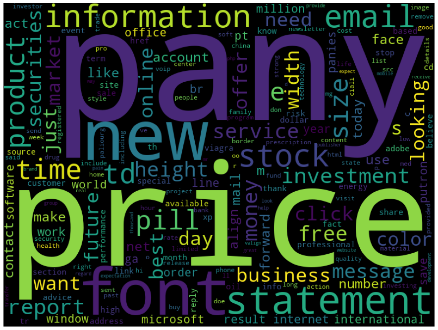

```python
#Word Cloud for Spam Emails
spam_emails = ' '.join(X_train[Y_train==1]) #Create one list consisting of all Spam emails.

spam_wc = WordCloud(width=800,
                         height=600,
                         stopwords=ENGLISH_STOP_WORDS,collocations=False).generate(spam_emails)

# Display the generated image:
plt.subplots(figsize=(16, 12))
plt.imshow(spam_wc)
plt.axis("off")
plt.show()
```

The top 20 words in the Spam Emails were also looked at. This is shown below as it shows their relative frequencies. We can see that the word "pany" also has a very high relative frequency when compared to the other words. Other words like "stock","product","pill","money","service" were also in the top 20. These words already gives us an idea of the Spam mails as they seem like mails to purchase something.

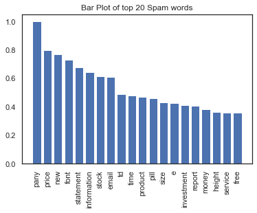

```python
#get top 20 Spam words
#converted dictionary to a list then sliced list and finally converted it back to a dictionary
top_20_spam=dict(list(spam_wc.words_.items())[:20])

plt.bar(top_20_spam.keys(),top_20_spam.values())
plt.xticks(rotation='90')
plt.title("Bar Plot of top 20 Spam words")
plt.show()
```

## Using Bigrams

Using bigrams for the Ham mails, we dont really see a difference in the kinds of words that we saw when unigram was used. We can see here that the words "ect" and "hou" are still the ones with very high frequencies. However, bigrams like "daren farmer", "farmer hou", "original message" can now be seen. A bar plot that shows these words and their relative frequencies is also shown below.

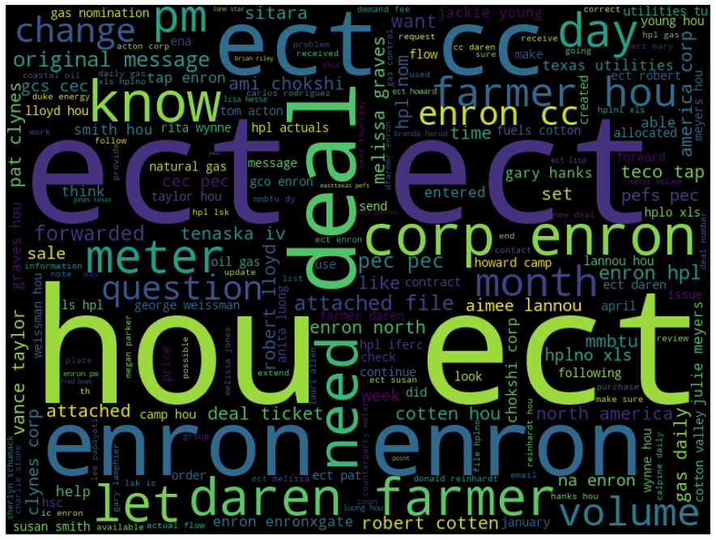

```python
#Word Cloud for Ham Emails
ham_emails = ' '.join(X_train[Y_train==0])

ham_wc = WordCloud(width=800,
                         height=600,
                         stopwords=ENGLISH_STOP_WORDS,collocations=True,collocation_threshold=3).generate(ham_emails)

# Display the generated image:
plt.subplots(figsize=(16, 12))
plt.imshow(ham_wc)
plt.axis("off")
plt.show()
```

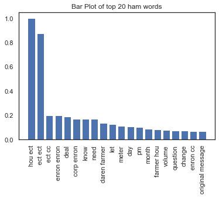

```python
#Get top 20 Ham words
#converted dictionary to a list then sliced list and finally converted it back to a dictionary
top_20_ham=dict(list(ham_wc.words_.items())[:20])

plt.bar(top_20_ham.keys(),top_20_ham.values())
plt.xticks(rotation='90')
plt.title("Bar Plot of top 20 ham words")
plt.show()
```

For the bigram words in the Spam emails, words like "pills pills", "looking statement","forward looking", "investment advice " also have relatively higher frequencies. The bar plot below also shows this.

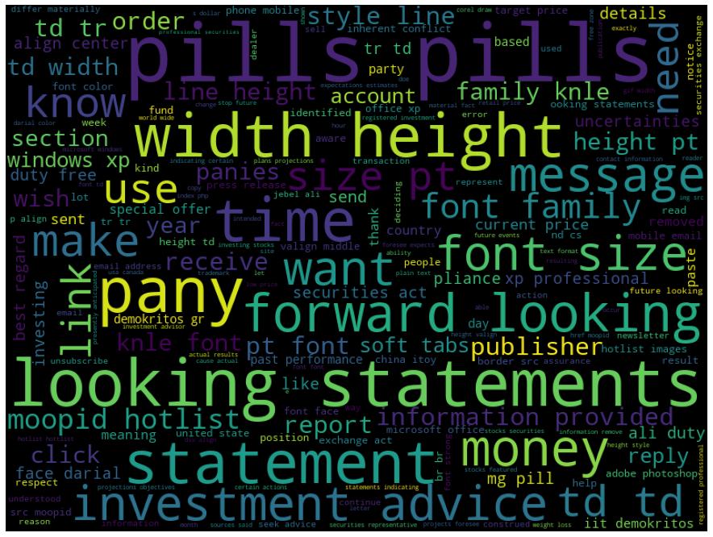

```python
#Word Cloud for Spam Emails
spam_emails = ' '.join(X_train[Y_train==1])

spam_wc = WordCloud(width=800,
                         height=600,
                         stopwords=ENGLISH_STOP_WORDS,collocations=True,collocation_threshold=3).generate(spam_emails)

# Display the generated image:
plt.subplots(figsize=(16, 12))
plt.imshow(spam_wc)
plt.axis("off")
plt.show()
```

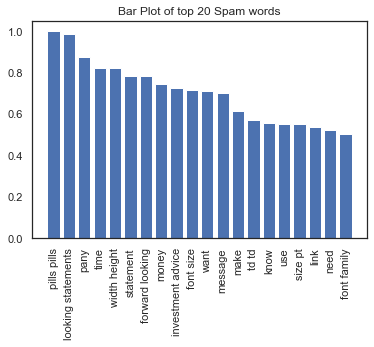

```python
#get top 20 Spam words
#converted dictionary to a list then sliced list and finally converted it back to a dictionary
top_20_spam=dict(list(spam_wc.words_.items())[:20])

#plt.bar(*zip(*top_10_spam.items()))
#plt.show()
plt.bar(top_20_spam.keys(),top_20_spam.values())
plt.xticks(rotation='90')
plt.title("Bar Plot of top 20 Spam words")
plt.show()
```

Next thing I did was to compare the distribution of the length of both Ham and Spam emails. From the histogram below, it can be seen that both classes follow the same kind of distribution as they are both skewed to the right. It also shows that for the Ham mails, they mostly have a lenth of about 0-250 while for Spam mails, their length is within 0-500 majorly.

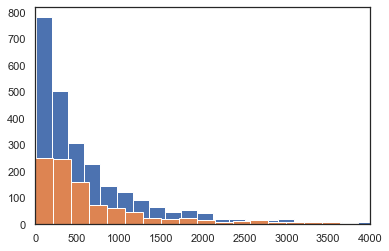

```python
plt.hist(X_train[Y_train==0].apply(lambda x:len(x)),bins=100) #plot the histogram of the length of Ham mails
plt.hist(X_train[Y_train==1].apply(lambda x:len(x)),bins=100) #plot the histogram of the length of Spam mails
plt.xlim(0,4000)
plt.show()
```

The boxplot below also shows a similar distribution between both classes. We can also see that they both have one outlier with a length significantly far from the rest. The outlier for Spam is the longest mail as can be seen below also.

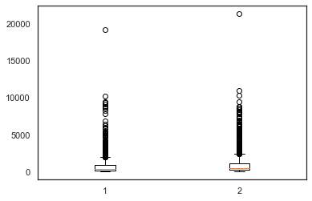

```python
plt.boxplot([X_train[Y_train==0].apply(lambda x:len(x)),X_train[Y_train==1].apply(lambda x:len(x))])
plt.show()
```

Also, reducing the scale on the y axis also shows that the median length for Spam is slighly above that for Ham. This means that Spam mails are longer than Ham mails.

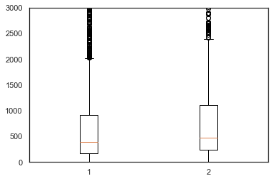

```python
plt.boxplot([X_train[Y_train==0].apply(lambda x:len(x)),X_train[Y_train==1].apply(lambda x:len(x))])
plt.ylim(0,3000) #Set y axis to 0-3000
plt.show()
```

The below shows that the maximum length for Spam mails is 21,420 and the maximum for Ham is 19,249.

```python
X_train[Y_train==1].apply(lambda x:len(x)).describe()
```

```
count    1068.000000
mean     1099.422285
std      1726.384694
min      2.000000
25%      233.250000
50%      469.000000
75%      1102.000000
max      21420.000000
Name: Emails, dtype: float64
```

```python
X_train[Y_train==0].apply(lambda x:len(x)).describe()
```

```
count    2552.000000
mean     733.499216
std      1043.853204
min      10.000000
25%      169.000000
50%      391.500000
75%      910.500000
max      19249.000000
Name: Emails, dtype: float64
```

```python
emailCount=pd.DataFrame(X_train) #New dataframe with X_train data for computing the length of mails.
emailCount["count"]=emailCount["Emails"].apply(lambda x:len(x))
emailCount["Type"]=pd.DataFrame(Y_train)
```

```python
#emailCount[emailCount["count"]==21420]["Emails"]
```

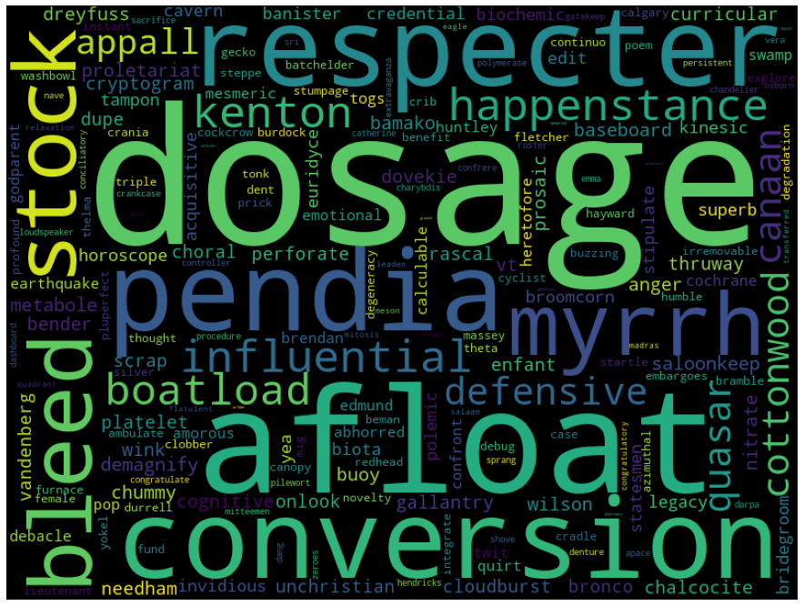

```python
#Word Cloud for Longest Emails
longestEmail = ' '.join(emailCount[emailCount["count"]==21420]["Emails"])

longestEmail_wc = WordCloud(width=800,
                         height=600,
                         stopwords=ENGLISH_STOP_WORDS,collocations=False).generate(longestEmail)

# Display the generated image:
plt.subplots(figsize=(16, 12))
plt.imshow(longestEmail_wc)
plt.axis("off")
plt.show()
```

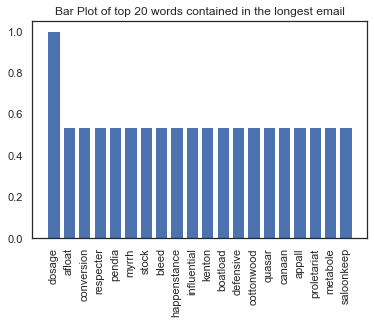

```python
#get top 20 words contained in the longest email
#converted dictionary to a list then sliced list and finally converted it back to a dictionary
top_20_longest=dict(list(longestEmail_wc.words_.items())[:20])

plt.bar(top_20_longest.keys(),top_20_longest.values())
plt.xticks(rotation='90')
plt.title("Bar Plot of top 20 words contained in the longest email")
plt.show()
```

# Feature Extraction

## Stemming

Stemming which is the process of reducing words to their root form was used in order to have better sets of features and not having same variant of a word as features. The NLTK library was used for this as I used the porterStemmer function to achieve this. This was done on both the train and test set.

```python
#Stemming- For finding the root words and using it to avoid having smae words with different forms as a feature
from nltk.stem.porter import PorterStemmer
stemmer = PorterStemmer()

def stemWords(words) :
    stemmedWords = list()
    for word in words :
        newWord = stemmer.stem(word)
        stemmedWords.append(newWord)
    return stemmedWords

X_train=pd.Series([" ".join(stemWords(doc.split())) for doc in X_train])
X_test=pd.Series([" ".join(stemWords(doc.split())) for doc in X_test])
```

# Pipeline for Feature Extraction and Modelling

A pipeline was used for both feature extraction and modelling as can be seen below. A varieties of models were used which includes:

1. Bernoulli Naive Bayes
2. Multinomial Naive Bayes
3. Gaussian Naive Bayes
4. Support Vector Machines

The process for all the model pipelines follows this process:

1. **Extract features from the document:**

As machine learning models cant take in text data, the first thing I did was to transform each word into a numerical feature using the bag of words model. I used count vectorizer from the SKLearn library for this as it generates all unique words from the document(emails) and then creates a matrix of the document(emails)(row) by the words(columns) which are the features, then the values are the number of occurence of the words in each of those documents. It also creates a dictionary of all the vocabularies from the documents(emails).

2. **TF-IDF Encoding:**

Since the emails are are of different lengths, this means that more weights would be given to longer documents as they would contain more words. In order to normalize this, I used the TfidfTransformer from SKLearn. What it does is to divide the count of each word in a document(email) by the total words in that document(email). Also, this also reduces the weigths of words that occurs in all of the document(emails) as they do not tell us much about the outcome class.

3. **Fit the data to the model:**

The last thing is to fit the model with this transformed data.

After creating the pipeline, using the cross_val_score function, I divided my training data into 10 folds using cv=10 and then performed a cross validation using the training data 10 times and then got an average of the model's accuracy. This was done to have a better accuracy of the model and not get an accuracy that was due to chance or due to the data split that was used.

The accuracy for the 4 models were then compared using a bar plot which can be seen below. The plot shows that Support Vector Machines has an higher accuracy when compared to the Naive Bayes variants.

```python
from sklearn.feature_extraction.text import CountVectorizer, TfidfTransformer
from sklearn.pipeline import Pipeline
from sklearn.naive_bayes import BernoulliNB, MultinomialNB, GaussianNB
from sklearn.preprocessing import FunctionTransformer
from sklearn.model_selection import cross_val_score,cross_val_predict
from sklearn.linear_model import SGDClassifier
from sklearn.model_selection import GridSearchCV
```

## Pipeline for Naive Bayes

### Bernoulli Naive Bayes

```python
bernoulliModel= Pipeline([("countVect",CountVectorizer()), #Countvectorizer instance
                         ("tfidEncd", TfidfTransformer()), #Tfidf Transformer instance
                         ("model", BernoulliNB()) #Bernoulli model instance
                         ])
```

```python
cv_bernoulliModel = cross_val_score(bernoulliModel,X_train,Y_train,cv=10)
cv_bernoulliModel.mean()
```

```
0.8298444570280017
```

### Multinomial Naive Bayes

```python
multinomialModel= Pipeline([("countVect",CountVectorizer()),
                         ("tfidEncd", TfidfTransformer()),
                         ("model", MultinomialNB())
                         ])
```

```python
cv_multinomialModel = cross_val_score(multinomialModel,X_train,Y_train,cv=10)
cv_multinomialModel.mean()
```

```
0.8668542542844632
```

### Gaussian Bayes

```python
gaussianModel= Pipeline([("countVect",CountVectorizer()),
                         ("tfidEncd", TfidfTransformer()),
                         ("convertDense",FunctionTransformer(lambda x: x.todense(), accept_sparse=True,validate=True)),
                         ("model", GaussianNB())
                         ])
```

```python
cv_gaussianModel = cross_val_score(gaussianModel,X_train,Y_train,cv=10)
cv_gaussianModel.mean()
```

```
0.9450351078299424
```

## Pipeline for Support Vector Machines

```python
svmModel= Pipeline([("countVect",CountVectorizer()),
                         ("tfidEncd", TfidfTransformer()),
                         ("model", SGDClassifier())
                         ])
```

```python
cv_svmModel = cross_val_score(svmModel,X_train,Y_train,cv=10)
cv_svmModel.mean()
```

```
0.9825935947050908
```

```python
modelScores={
    "bernoulli":cv_bernoulliModel.mean()*100, #Multiply the score by 100 to get it in percentage.
    "multinomial" :cv_multinomialModel.mean()*100,
    "gaussian" :cv_gaussianModel.mean()*100,
    "SVM" :cv_svmModel.mean()*100
}
```

This shows the accuracies across the various models used

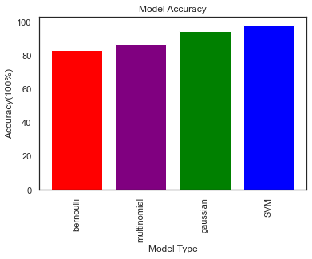

```python
#Plot of Models Accuracy
plt.bar(modelScores.keys(),modelScores.values(),color=["red","purple","green","blue"])# Assign colors to the bars
plt.xticks(rotation='90')
plt.title("Model Accuracy")
plt.xlabel('Model Type')
plt.ylabel('Accuracy(100%)')
plt.show()
```

# Parameter Tuning using Grid Search

In order to get better results, I decided to tune the various models across various parameters using a grid search. The GridSearchCV was used for this from the SKLearn library also.

The parameters I tuned across all the pipelines are:

1. **Ngram Range:**

I gave as parameters "unigram" and "bigram" to the count vectorizer in order to determine which was better.

2. **Maximum Features:**

Maximum features to use for the count vectorizer was also given as parameters with the following sets of values:

- 1,000
- 5,000
- 10,000
- None
3. **Stop Words:**

Stop words are words which do not add much information to sentences hence, they are most times not useful in text classification problems. What I did was to remove "english" stopwords and also not to remove stopwords in order to determine which would give better results.

4. **TFID Encoding:**

Finally, I passed both "True" and "False" in order to determine which gave better accuracy. Whether it was when tfid transformer was used or not.

The code is shown below.

### Bernoulli Model Tuning

```python
bernoulli_parameters = {'countVect__ngram_range': [(1, 1), (1, 2)], #vect__ngram_range; here we are telling to use unigram and bigrams and choose the one which is optimal.
              'countVect__max_features': (1000,5000,10000,None),
              'countVect__stop_words': ("english",None),
             'tfidEncd__use_idf': (True, False)
             }
```

```python
gs_bernoulli = GridSearchCV(bernoulliModel, bernoulli_parameters,cv=5)
gs_bernoulli = gs_bernoulli.fit(X_train,Y_train)
```

```python
print(gs_bernoulli.best_score_) #get best score
print(gs_bernoulli.best_params_) #get dictionary of best parameters
```

```
0.9400552486187845
{'countVect__max_features': 5000, 'countVect__ngram_range': (1, 2), 'countVect__stop_words': None, 'tfidEncd__use_idf': True}
```

### Multinomial Model Tuning

```python
multinomial_parameters = {'countVect__ngram_range': [(1, 1), (1, 2)], #vect__ngram_range; here we are telling to use unigram and bigrams and choose the one which is optimal.
              'countVect__max_features': (1000,5000,10000,None),
              'countVect__stop_words': ("english",None),
             'tfidEncd__use_idf': (True, False)
             }
```

```python
gs_multinomial = GridSearchCV(multinomialModel, multinomial_parameters,cv=5)
gs_multinomial = gs_multinomial.fit(X_train,Y_train)
```

```python
print(gs_multinomial.best_score_)
print(gs_multinomial.best_params_)
```

```
0.9676795580110498
{'countVect__max_features': 10000, 'countVect__ngram_range': (1, 2), 'countVect__stop_words': 'english', 'tfidEncd__use_idf': True}
```

### Gaussian Model Tuning

```python
gaussian_parameters = {'countVect__ngram_range': [(1, 1), (1, 2)], #vect__ngram_range; here we are telling to use unigram and bigrams and choose the one which is optimal.
              'countVect__max_features': (1000,5000,10000,None),
              'countVect__stop_words': ("english",None),
             'tfidEncd__use_idf': (True, False)
             }
```

```python
gs_gaussian = GridSearchCV(gaussianModel, gaussian_parameters,cv=3)
gs_gaussian = gs_gaussian.fit(X_train,Y_train)
```

```python
print(gs_gaussian.best_score_)
print(gs_gaussian.best_params_)
```

```
0.9751381215469613
{'countVect__max_features': None, 'countVect__ngram_range': (1, 2), 'countVect__stop_words': 'english', 'tfidEncd__use_idf': False}
```

### Support Vectors Model Tuning

```python
svm_parameters = {'countVect__ngram_range': [(1, 1), (1, 2)], #vect__ngram_range; here we are telling to use unigram and bigrams and choose the one which is optimal.
              'countVect__max_features': (1000,5000,10000,None),
              'countVect__stop_words': ("english",None),
             'tfidEncd__use_idf': (True, False)
             }
```

```python
gs_svm = GridSearchCV(svmModel, svm_parameters,cv=5)
gs_svm = gs_svm.fit(X_train,Y_train)
```

```python
print(gs_svm.best_score_)
print(gs_svm.best_params_)
```

```
0.9842541436464088
{'countVect__max_features': None, 'countVect__ngram_range': (1, 2), 'countVect__stop_words': 'english', 'tfidEncd__use_idf': True}
```

```python
#Tuned Models Scores
tunedModelScores={
    "bernoulli":gs_bernoulli.best_score_*100,
    "multinomial" :gs_multinomial.best_score_*100,
    "gaussian" :gs_gaussian.best_score_*100,
    "SVM" :gs_svm.best_score_*100
}
```

The bar plot below shows that all the model's accuracy increased and they all have scores of above 90. The scores are now almost similar, however the support vector machine model has a better accuracy of 98.4%

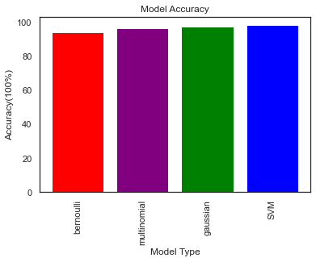

```python
#Plot of Models Accuracy
plt.bar(tunedModelScores.keys(),tunedModelScores.values(),color=["red","purple","green","blue"])#To assign colors to each bar
plt.xticks(rotation='90')
plt.title("Model Accuracy")
plt.xlabel('Model Type')
plt.ylabel('Accuracy(100%)')
plt.show()
```

## Selecting Best Model

Based on the accuracy from the tuned models, I settled with the SVM model as it has a better accuracy. The next step was to create a new pipeline using the best parameters gotten from the grid search. The model's accuracy was then evaluated using 10 cross validation validation on the train data. A mean accuracy of 98.45% was gotten which is slightly more than the 98.26% gotten before the tuning. Also, the accuracy score for the 10 times it was evaluated is plotted below.

```python
svmModelFinal= Pipeline([("countVect",CountVectorizer(ngram_range=(1,2),stop_words="english")),
                         ("tfidEncd", TfidfTransformer()),
                         ("model", SGDClassifier())
                         ])
```

```python
cv_svmModelFinal = cross_val_score(svmModelFinal,X_train,Y_train,cv=10)
cv_svmModelFinal.mean()
```

```
0.9845272963625495
```

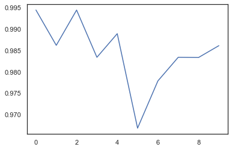

```python
plt.plot(cv_svmModelFinal)
plt.show()
```

## Making Predictions

```python
svmModelFinal=svmModelFinal.fit(X_train,Y_train)
Y_pred=svmModelFinal.predict(X_test)
```

# Model Evaluation

The model was then used to make predictions on the unseen test data. An accuracy of 98.90% was gotten on the test set.

```python
from sklearn import metrics
print('\nClasification report:\n', metrics.classification_report(Y_test, Y_pred))
```

```
Clasification report:
               precision    recall  f1-score   support

           0       1.00      0.99      0.99      1120
           1       0.97      0.99      0.98       432

    accuracy                           0.99      1552
   macro avg       0.98      0.99      0.99      1552
weighted avg       0.99      0.99      0.99      1552
```

A confusion matrix was also plotted. This shows the following:

1. 1106 emails were correctly classified as ham (TRUE NEGATIVE)
2. 429 emails were correctly classified as Spam (TRUE POSITIVE)
3. 3 emails were classified as Ham when it was Spam (FALSE NEGATIVE)
4. 14 emails were classified as Spam when it was Ham (FALSE POSITIVE)

```python
conMatrix=metrics.confusion_matrix(Y_test, Y_pred)
conMatrix
```

```
array([[1106,   14],
       [   3,  429]])
```

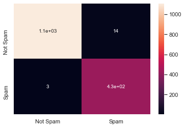

```python
sns.heatmap(conMatrix , annot = True,xticklabels=['Not Spam', 'Spam']
            , yticklabels=['Not Spam', 'Spam'])
```

```python
metrics.accuracy_score(Y_test, Y_pred)
```

```
0.9890463917525774
```

# Conclusion

Even with an accuracy of 98.90%, from the confusion matrix, it shows that 14 mails were wrongly classified as Spam when they were not and they end up in the Spam folder. This cost is higher as it means important and legitimate emails can end up in the Spam folder. However, having a f1-score of 0.99 for Ham class and 0.98 for Spam class is very good.